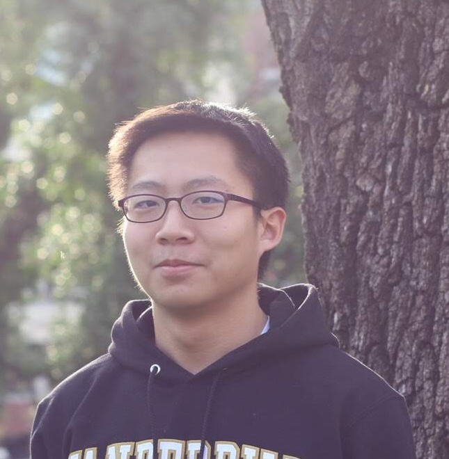

# Jackie Chang

## Bio

I am a research assistant in [Yu-Chao Wang’s Lab](https://yuchao.web.nycu.edu.tw/) at [National Yang Ming Chiao Tung University](https://www.nycu.edu.tw/nycu/en/index). In the lab, I am studying Internal Tandem Duplication in cancers by integrating and analyzing multi-omics data with statistical and machine learning approaches.

During my master’s I studied Host-Virus Interaction, specifically through the post translational modification ADP-ribosylation, of SARS-CoV-2, Chikungunya, and Influenza with [Anthony Leung](https://publichealth.jhu.edu/faculty/2498/anthony-k-l-leung) at the [Johns Hopkins Bloomberg School of Public Health](https://publichealth.jhu.edu/).

## Education

**Johns Hopkins University** | Baltimore, MD

M.S. in Bioinformatics | December 2024

**Vanderbilt University** | Nashville, TN

## Research Experience

**Johns Hopkins Bloomberg School of Public Health** | Masters Student | Anthony Leung Lab | August 2023 - December 2024

**Vanderbilt University Medical Center** | Undergraduate Researcher | Bingshan Li Lab | June 2021 - May 2022

**Academia Sinica** | Undergraduate Researcher | Paul Verslues Lab | July 2020 - June 2021

## Interests

- Multi-Omics Integration
- Host-pathogen Interactions
- Hybrid research approach combining experimental methods with computational and quantitative techniques

## Publications

R. Raja, B. Biswas, R. Abraham, Y. Wang, **C-Y. Chang**, I. A. Hendriks, S. C. Buch-Larsen, H. Liu, X. Yang, C. Wang, H. Vu, A. Hamacher-Brady, D. Cai, A.K.L. Leung. **Interferon-Induced PARP14-Mediated ADP-Ribosylation in p62 Bodies Requires an Active Ubiquitin-Proteasome System.** *Embo J.* [DOI: 10.1038/s44318-025-00421-4](https://doi.org/10.1038/s44318-025-00421-4)

Z. Zhang, I. Uribe, K.A. Davis, R.L. McPherson, G.P. Larson, M. Badiee, V. Tran, M.P. Ledwith, E. Feltman, S. Yú, Y. Caì, **C-Y. Chang**, X. Yang, Z. Ma, P. Chang, J.H. Kuhn, A.K.L. Leung, A. Mehle. **Global remodeling of ADP-ribosylation by PARP1 suppresses influenza A virus infection.** *Nature Communications.* [DOI: 10.1038/s41467-025-66136-6](https://doi.org/10.1038/s41467-025-66136-6)

R. Abraham, T. Kim, **C-Y. Chang**, L. Pieterse, B.H. Nguyen, E. Sreekumar, L.C. Morales, R.E. Williams, M.S. Cohen, A.K.L. Leung, D.E. Griffin. **Cell type-dependent induction of interferon and ADP-ribosylation in astrocytes and neurons during chikungunya virus infection.**